# Clustering Homework

```r
library(tidyverse)
library(tidyverse)
library(janitor)
```

# 1

You have been provided some customer data from a shopping centre. Do some exploratory analysis on the data. Comment on findings.

```r
mall_data <- read_csv("data/mall_customers.csv") %>%
  clean_names()
```

[output not shown]

[output not shown]

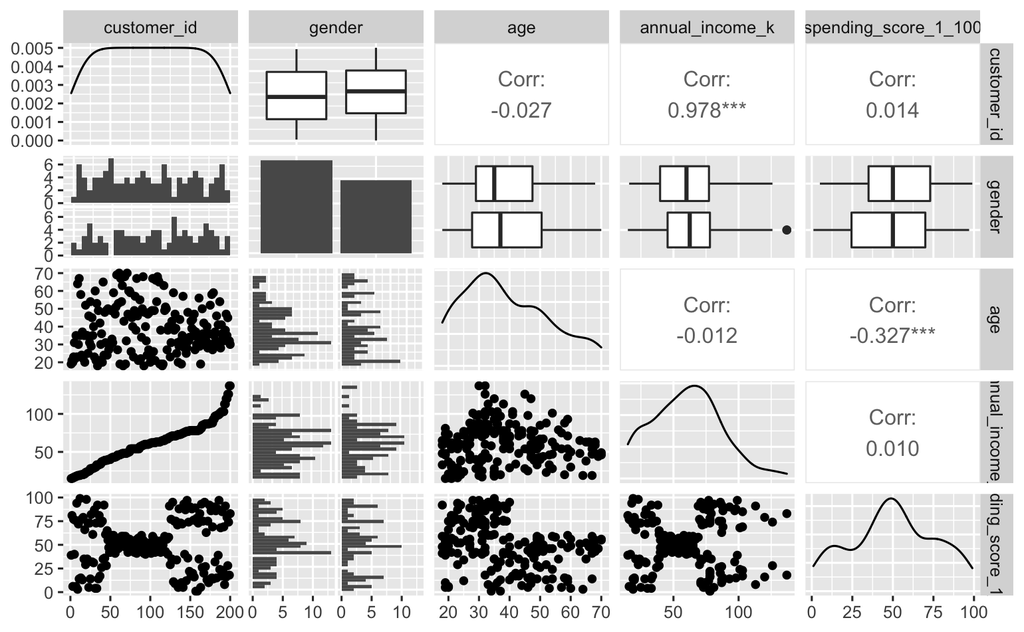

```r
ggpairs(mall_data)
```

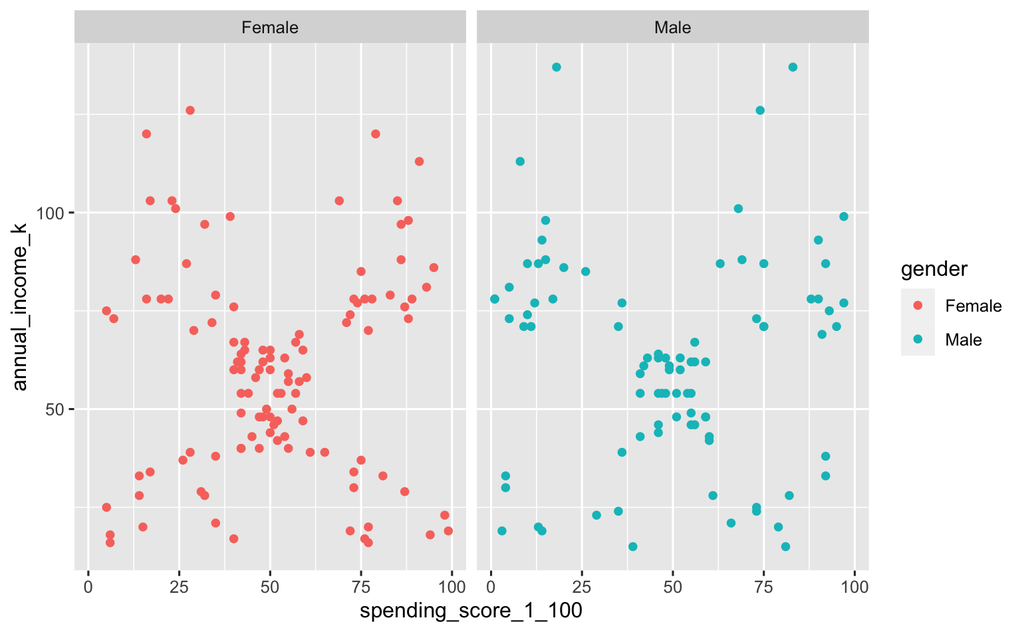

Patterns between spending score and annual income look consistent across both genders, so likely not a factor here. It seems like women have a higher spending score, but average income is less - however there are more female customers in the data than male.

The plot of the data shows potential for 5 distinct groups, one at each corner and one in the middle, but we should investigate further.

# 2

We are interested in creating a marketing campaign to target customers based on their spending score and annual income. Perform a k-means clustering to find if there are meaningful clusters in the data to target the customers.

## Perform k-means clustering and chose a value of k.

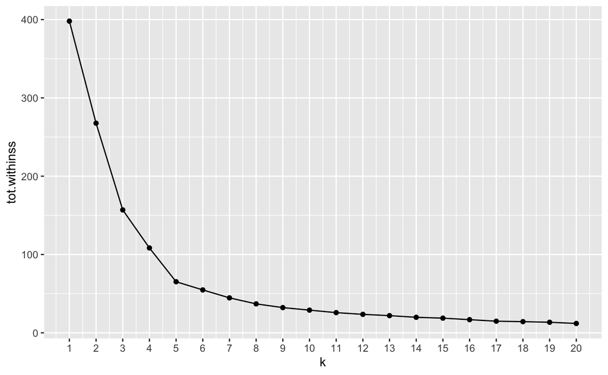

No clear elbow here apart from maybe 3 or 5, best to look at other plots.

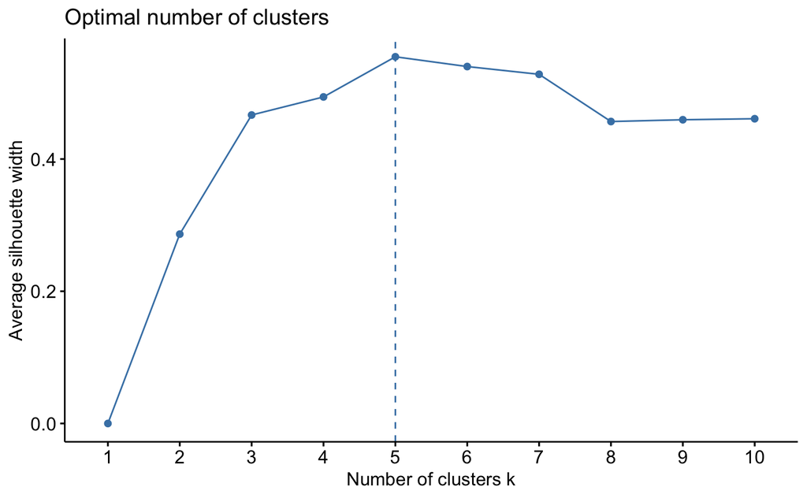

Looks like 5 is the best in this one, one more plot.

```
Clustering k = 1,2,..., K.max (= 10): .. done
Bootstrapping, b = 1,2,..., B (= 100)  [one "." per sample]:
.................................................. 50
.................................................. 100
```

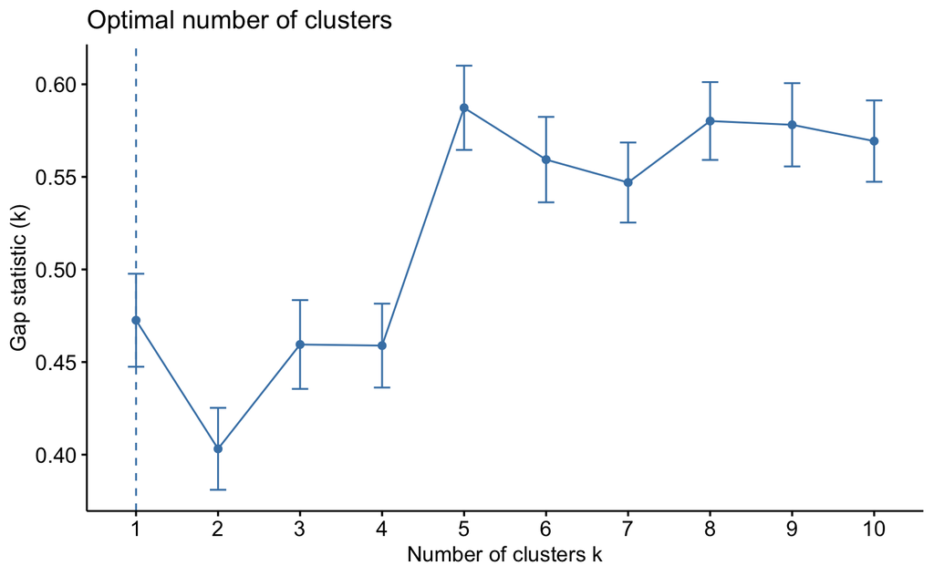

```r
fviz_nbclust(mall_data_scale,
             kmeans,
             method = "gap_stat",
             nstart = 25)
```

For some reason dotted line by 1 here, but 5 looks better and also looks good on the other 2 plots.

# Visualise the clustering for your chosen value of k.

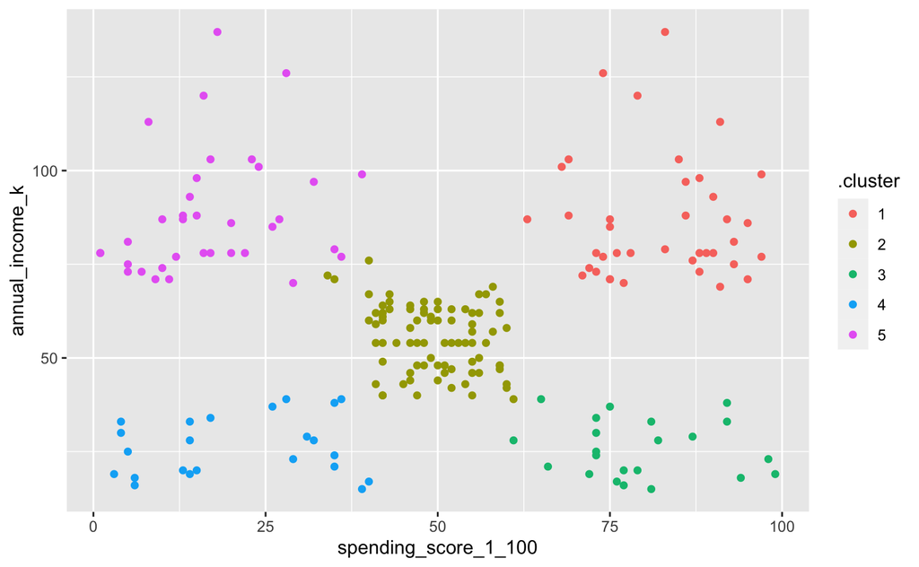

# Do you think the clustering seems a good fit for this data?

Yes! All of the clusters look like they fit well with the data.

# Comment on the attributes on one or two of the clusters (maybe even give them a label if you like - like in section 4.1 of the ‘Segmentation & clustering intro’ lesson).

The “Window Shopper” - Low income & low spending score - perhaps younger customers hanging around at the mall, or people who are less well off scoping out their dream purchases.

The “Should Probably Try Amazon Prime” - Low income & high spending score - why are you spending so much at the mall? Probably suckeed in quite easily by a good deal or black friday sales.